# Behöver vi referensperiod

K2 has proven to be an effective way at detecting anomalies in district heating. However, one of the caveats of K2 is the need of a reference period. The algorithm behind the K2 software, built by Smart Energi, first trains a segmented regression model on a reference period. In the next step it applies that model to new unseen data and compares the model on the reference period to the new data.

The crux is that this reference period has to be manually selected, and if you have a couple of thousand metering points this task is impossible. Often users will use the first year in the data as the reference period.

The question we will try to answer in this notebook is if the use of reference period is necessary.

## What do we want to detect?

The two primary objectives of K2 are to 1) detect anomalies and create alarms for these and 2) detect trend changes.

Anomalies are detected when new observations deviate too much from their expected values. More specifically, when we use the model trained on the reference data on the new unseen data and the new data deviates from the expected values of the model, we create an alarm.

There is no explicit method for detecting trend changes in K2. Nevertheless, trend changes are usually associated with some kind of data drift, that is, that the new unseen data is different than the reference period. This is usually detected when there are more alarms than usual.

We can illustrate this by looking at reference and test data for one metering-point.

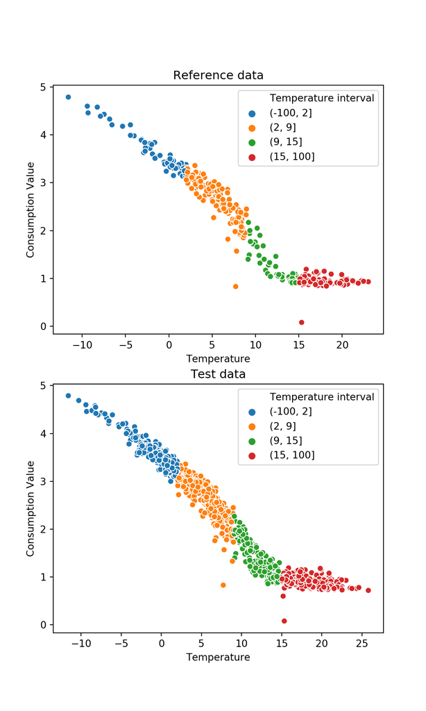

When we apply a segmented regression model to the data we get a fitted line, from which we can calculate expected values for the test data.

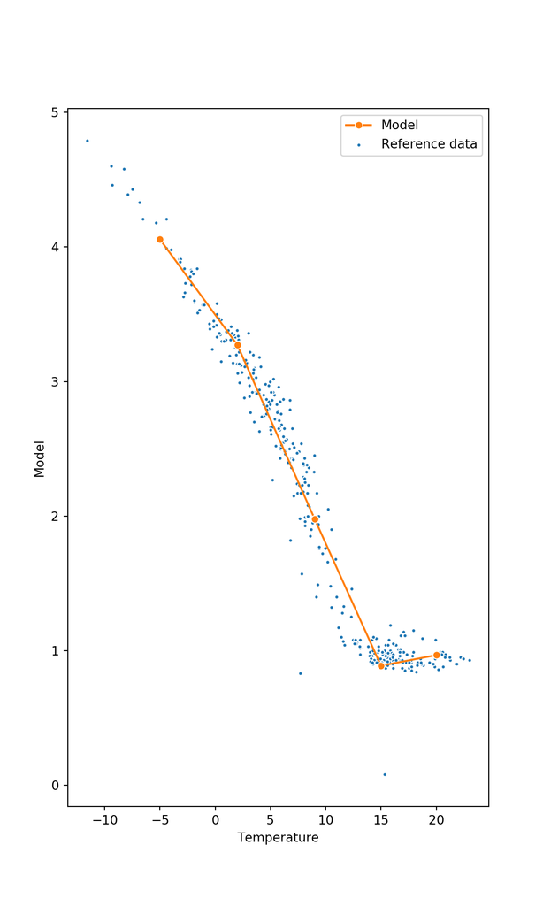

```python
def fill_points_with_data(df):
    points = []
    for index, row in df.iterrows():
        point = Point()
        point.temp = float(row['Temperature'])
        try:
            point.reading = row['Consumption Value']
            point.timestamp = row['Timestamp']
            point.consumption_timestamp = row['Consumption From']
            point.breakpoints = BREAKPOINTS
        except:
            None
        points.append(point)
    return points

points_energy = fill_points_with_data(tds9_ref)
points_energy_test = fill_points_with_data(tds9)

# Skapa grupp för referensdata
g_energy = Group()
g_energy.set_breakpoints(BREAKPOINTS)
g_energy.set_points(points_energy)

# Skapa grupp även för test data (används senare)
g_energy_test = Group()
g_energy_test.set_breakpoints(BREAKPOINTS)
g_energy_test.set_points(points_energy_test)

koff = g_energy.calcKoff()
g_energy.updatePointRegression(koff)

#Skapa data grupp för breakpoints för visualisering av modell
breakpoint_df = pd.DataFrame({'Temperature' : BREAKPOINTS})
points_bp = fill_points_with_data(breakpoint_df)
bp_group = Group()
bp_group.set_breakpoints(BREAKPOINTS)
bp_group.set_points(points_bp)
bp_group.updatePointRegression(koff)

ref_modell = pd.DataFrame([[point.reading, point.regression, point.temp] for point in g_energy.points], columns=['Consumption', 'Model', 'Temperature'])
bp_modell = pd.DataFrame([[point.reading, point.regression, point.temp] for point in bp_group.points], columns=['Consumption', 'Model', 'Temperature'])

import itertools
palette = sns.color_palette()

sns.scatterplot(x = 'Temperature', y = 'Consumption', marker='.', data = ref_modell, label = 'Reference data')
sns.lineplot(x = 'Temperature', y='Model', marker = 'o', data = bp_modell, color = palette[1], label = 'Model')
plt.legend()
plt.show();
```

If we apply this regression line to the dataset we get the following alarms.

```python
g_energy_test.updatePointRegression(koff)
test_modell = pd.DataFrame([[point.reading, point.regression, point.temp] for point in g_energy.points], columns=['Mätvärde', 'Modell', 'Temperatur'])

def larm(row, std_cutoff=2.):
    standard_deviation = row['stdav']
    diff = row['resid']
    max_standard_deviation = std_cutoff
    if (abs(diff)/standard_deviation) > max_standard_deviation:
        return 'critical'
    else:
        return 'ok'

# calculate std av for this group
stddev = StandardDeviation(BREAKPOINTS) # Initierar standard deviation klass
stddev.import_from_group(g_energy) # För över reading, regression, temp från grupp till stddev klass, lagras som pandas dataframe
stddev.calc_standard_deviation() # Beräknar standardavvikelsen per temperaturintervall
```

```
## temp_intervall  group  property
## (-100, 2]       1      not-known    0.105717
## (2, 9]          1      not-known    0.218645
## (9, 15]         1      not-known    0.180127
## (15, 20]        1      not-known    0.116806
## (20, 100]       1      not-known    0.042927
## Name: stdav, dtype: float64
```

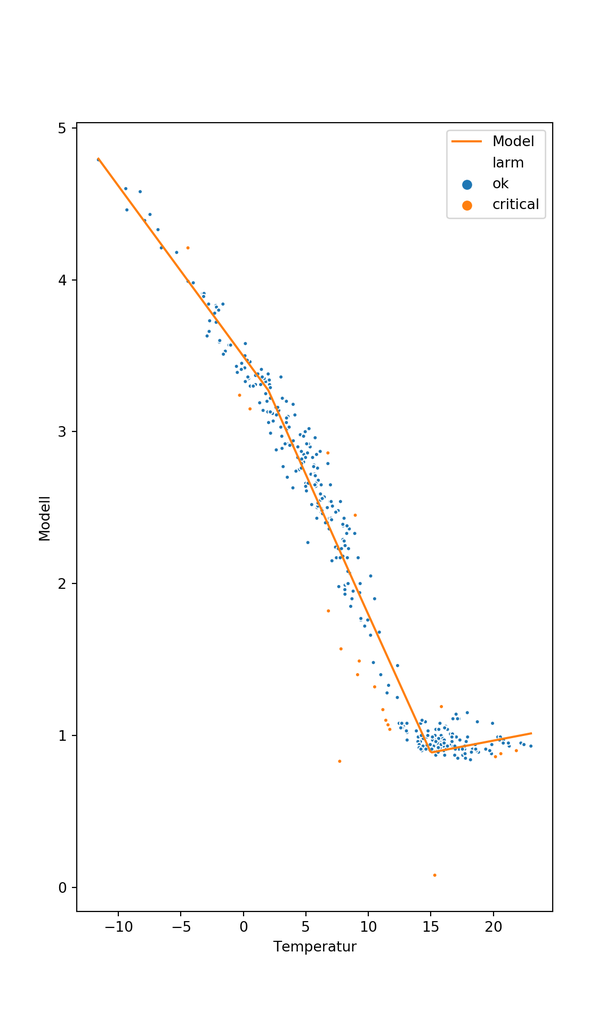

```python
test_modell['resid'] = test_modell['Mätvärde'] - test_modell['Modell']
test_modell['temp_intervall'] = pd.cut(ref_modell['Temperature'], [-100] + BREAKPOINTS[1:] + [100])

std = pd.DataFrame(stddev._dataframe.groupby(['temp_intervall'])[
            'consumption_norm'].std().rename('stdav'))
test_modell = test_modell.join(std, on = 'temp_intervall')
test_modell['larm'] = test_modell.apply(lambda row: larm(row), axis=1)

sns.scatterplot(x ='Temperatur', y = 'Mätvärde', hue='larm', marker = '.', data = test_modell)
sns.lineplot(x = 'Temperatur', y='Modell', data = test_modell, color = palette[1], label = 'Model')
plt.show();
```

But if we abandon the idea of a reference period, and instead treat both the reference data and the test data as one dataset, fit a segmented regression on in similar fashion investigate the residuals, how will that change the alarms?

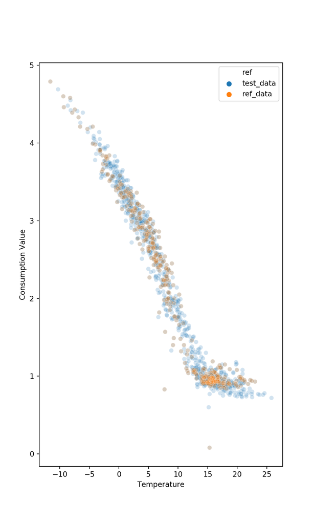

```python
tds9 = pd.read_csv('data/TDS9_test.csv', sep=';')
tds9['Timestamp'] = pd.to_datetime(tds9.Timestamp)
tds9['Consumption From'] = pd.to_datetime(tds9['Consumption From'])
tds9['Consumption To'] = pd.to_datetime(tds9['Consumption To'])

tds9 = tds9[(tds9.Property=='energy') & (tds9.Value > 0.)]
tds9['ref'] = 'test_data'

tds9_ref = pd.read_csv('data/TDS9_ref2.csv', sep=';')
tds9_ref['Timestamp'] = pd.to_datetime(tds9_ref.Timestamp)
tds9_ref['Consumption From'] = pd.to_datetime(tds9_ref['Consumption From'])
tds9_ref['Consumption To'] = pd.to_datetime(tds9_ref['Consumption To'])
tds9_ref = tds9_ref[tds9_ref.Property=='energy']
tds9_ref['ref'] = 'ref_data'

tds9['Temperature interval'] = pd.cut(tds9['Temperature'], [-100] + BREAKPOINTS[1:-1] + [100])
tds9_ref['Temperature interval'] = pd.cut(tds9_ref['Temperature'], [-100] + BREAKPOINTS[1:-1] + [100])

tds9_full = tds9_ref.append(tds9)

tds9_full = tds9.append(pd.DataFrame(data = tds9_ref), ignore_index=True)

sns.scatterplot(x = 'Temperature', y = 'Consumption Value', hue = 'ref', data = tds9_full, alpha = 0.2)

plt.show()
```

So, let’s fit a segmented regression to this data.

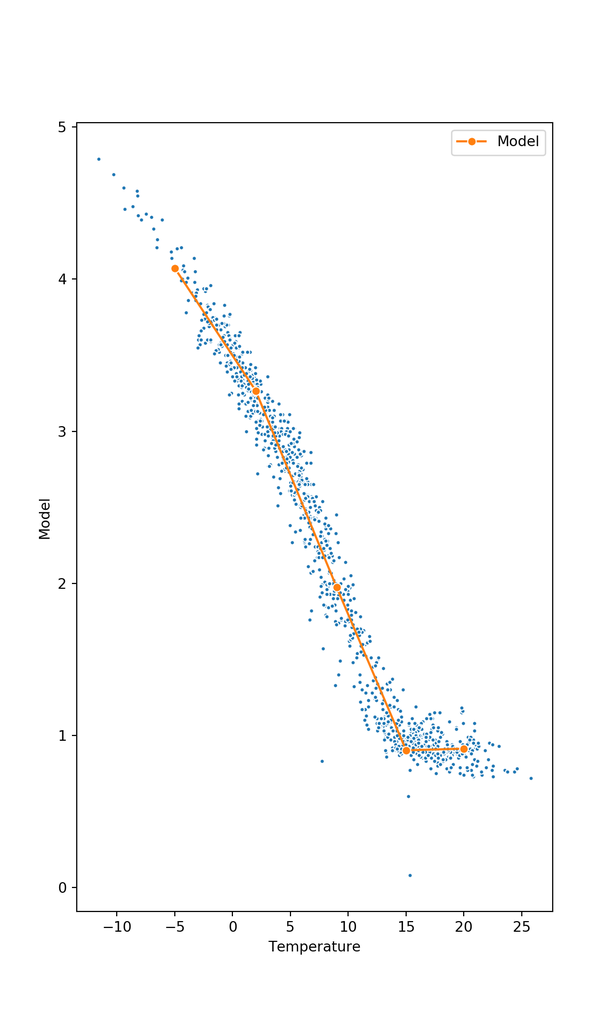

```python
def fill_points_with_data(df):
    points = []
    for index, row in df.iterrows():
        point = Point()
        point.temp = float(row['Temperature'])
        try:
            point.reading = row['Consumption Value']
            point.timestamp = row['Timestamp']
            point.consumption_timestamp = row['Consumption From']
            point.breakpoints = BREAKPOINTS
        except:
            None
        points.append(point)
    return points

points_energy = fill_points_with_data(tds9_full)
points_energy_test = fill_points_with_data(tds9)

# Skapa grupp för referensdata
g_energy = Group()
g_energy.set_breakpoints(BREAKPOINTS)
g_energy.set_points(points_energy)

# Skapa grupp även för test data (används senare)
g_energy_test = Group()
g_energy_test.set_breakpoints(BREAKPOINTS)
g_energy_test.set_points(points_energy_test)

koff = g_energy.calcKoff()
g_energy.updatePointRegression(koff)

#Skapa data grupp för breakpoints för visualisering av modell
breakpoint_df = pd.DataFrame({'Temperature' : BREAKPOINTS})
points_bp = fill_points_with_data(breakpoint_df)
bp_group = Group()
bp_group.set_breakpoints(BREAKPOINTS)
bp_group.set_points(points_bp)
bp_group.updatePointRegression(koff)

full_modell = pd.DataFrame([[point.reading, point.regression, point.temp] for point in g_energy.points], columns=['Consumption', 'Model', 'Temperature'])
bp_modell = pd.DataFrame([[point.reading, point.regression, point.temp] for point in bp_group.points], columns=['Consumption', 'Model', 'Temperature'])

import itertools
palette = sns.color_palette()

sns.scatterplot(x = 'Temperature', y = 'Consumption', marker='.', data = full_modell)
sns.lineplot(x = 'Temperature', y='Model', marker = 'o', data = bp_modell, color = palette[1], label = 'Model')
plt.legend()
plt.show();
```

How do the alarms look?

```python
def larm(row, std_cutoff=2.):
    standard_deviation = row['stdav']
    diff = row['resid']
    max_standard_deviation = std_cutoff
    if (abs(diff)/standard_deviation) > max_standard_deviation:
        return 'critical'
    else:
        return 'ok'

# calculate std av for this group
stddev = StandardDeviation(BREAKPOINTS) # Initierar standard deviation klass
stddev.import_from_group(g_energy) # För över reading, regression, temp från grupp till stddev klass, lagras som pandas dataframe
stddev.calc_standard_deviation() # Beräknar standardavvikelsen per temperaturintervall
```

```
## temp_intervall  group  property
## (-100, 2]       1      not-known    0.115395
## (2, 9]          1      not-known    0.204018
## (9, 15]         1      not-known    0.167284
## (15, 20]        1      not-known    0.105120
## (20, 100]       1      not-known    0.091109
## Name: stdav, dtype: float64
```

```python
test_modell['resid'] = full_modell['Consumption'] - full_modell['Model']
test_modell['temp_intervall'] = pd.cut(full_modell['Temperature'], [-100] + BREAKPOINTS[1:] + [100])
```

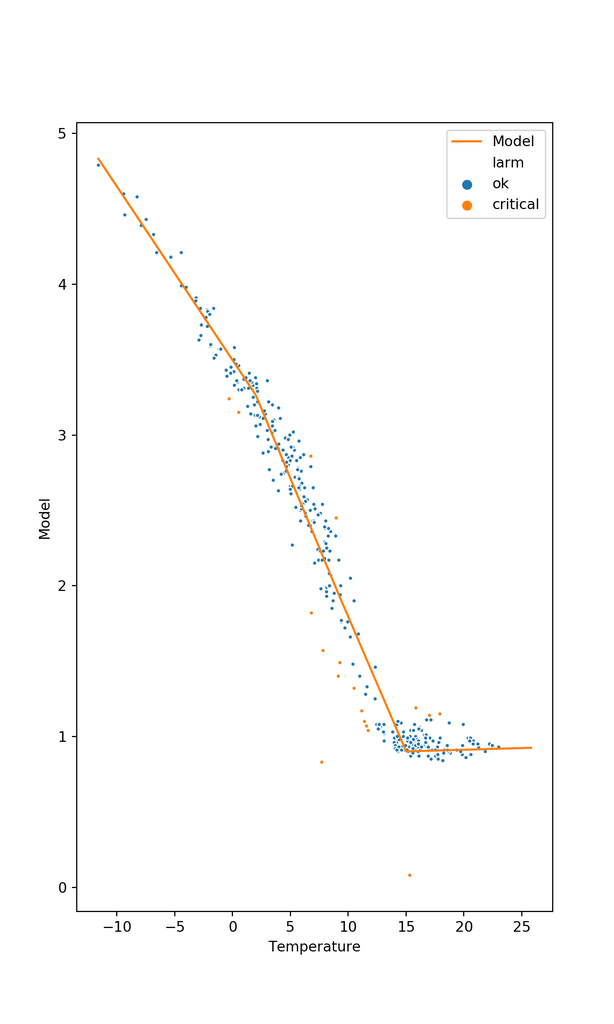

```python
std = pd.DataFrame(stddev._dataframe.groupby(['temp_intervall'])[
            'consumption_norm'].std().rename('stdav'))

full_modell['larm'] = test_modell.apply(lambda row: larm(row), axis=1)

sns.scatterplot(x ='Temperature', y = 'Consumption', hue='larm', marker = '.', data = full_modell)
sns.lineplot(x = 'Temperature', y='Model', data = full_modell, color = palette[1], label = 'Model')
plt.show();
```